# Workshop #1: Intro to R

October 02, 2014

### Programming = Magic

> *“It is about **learning to cast spells** that will summon up powerful daemons. People are impressed and awed by it.*

> *In the primitive societies of the corporate (or non-profit) world, people will bow before you, worship you and reward you with gold, if you have these magical skills.”*

> Hal Abelson and Gerald Sussman

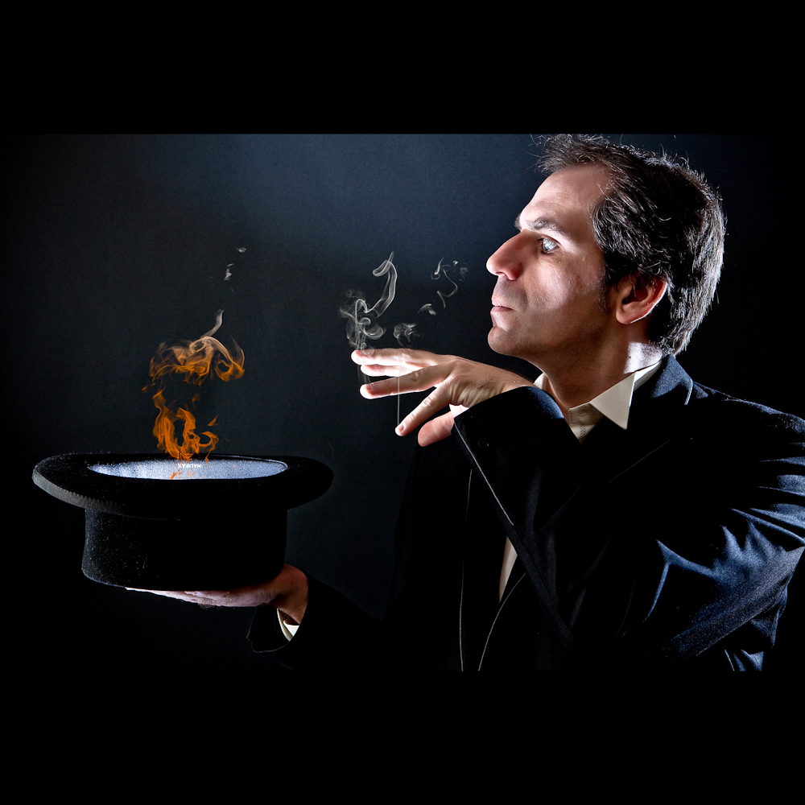

### So let's start with some magic!!

[figure not shown]

### Objective of the workshop series

### Data analysis workflow:

- Get data
- Clean data
- Transform data
- Analyze data (Modeling, Visualization)
- Communicate results

### Today's workshop:

### 10000 feet overview

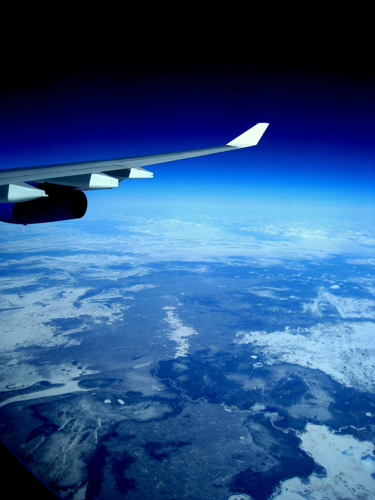

### Package

**R package** is the **equivalent** of a smartphone **app**.

Allows you to do more stuff.

[figure not shown]

### R & Rstudio

[figure not shown]

### System set-up

[figure not shown]